# Most Harzardous Driving Area of Canada?

## Introduction

Hundreds of thousands of Canadians get injured each year in car accidents, and thousands die each year from them. With this many accidents, it would be extremely beneficial to identify dangerous driving areas. Using the dataset "Hazardous Driving Areas" from GeoTab, we will investigate determine the most dangerous driving area in Canada, and more.

Geotab's "Hazardous Driving Areas" dataset publishes real-time and historical incident that captures both accident and near-miss events, for example, sudden braking. It provides measurements related to driving incidents, and generates a severity score to rank hazardous areas around the world.

## Objectives

- The purpose of this analysis is to determine the most hazardous driving areas in Canada.
- We define an area as a hazardous driving area if its severity score is larger than the average severity score and the number of incidents is higher than the average number of incidents.

## Data Summary

- **New Variables**
- Proportion of type of incidents to total incidents
- Total incidents of each type in each province
- Is an area hazardous
- **Modifications**
- Joined "Hazardous Driving Areas" dataset with a "Population of Canada" dataset

## Population

```
## # A tibble: 10 x 2
##    State                     Population
##    <chr>                          <dbl>
##  1 Canada                      36963854
##  2 Newfoundland and Labrador     527613
##  3 Nova Scotia                   957470
##  4 New Brunswick                 760744
##  5 Quebec                       8439925
##  6 Ontario                     14318750
##  7 Manitoba                     1346993
##  8 Saskatchewan                 1169752
##  9 Alberta                      4318772
## 10 British Columbia             4849442
```

## Total Areas in Each Province

```
## # A tibble: 10 x 2
##    State                     total
##    <fct>                     <int>
##  1 Alberta                     477
##  2 British Columbia            666
##  3 Manitoba                    601
##  4 New Brunswick               120
##  5 Newfoundland and Labrador    49
##  6 Nova Scotia                 243
##  7 Ontario                    5909
##  8 Prince Edward Island          2
##  9 Quebec                     2128
## 10 Saskatchewan                 46
```

## Total Number of Incidents

```
## # A tibble: 9 x 2
##   State                     total_inci
##   <fct>                          <int>
## 1 Alberta                         4968
## 2 British Columbia                6158
## 3 Manitoba                       15412
## 4 New Brunswick                   4467
## 5 Newfoundland and Labrador        977
## 6 Nova Scotia                     6617
## 7 Ontario                       109283
## 8 Quebec                         84791
## 9 Saskatchewan                     516
```

## Avgerage Severity Score and Average Number of Incidents

```
## # A tibble: 10 x 3
##    State                     avg_severity_score avg_num_inci
##    <fct>                                  <dbl>        <dbl>
##  1 Alberta                               0.109         10.4
##  2 British Columbia                      0.0660         9.25
##  3 Manitoba                              0.0863        25.6
##  4 New Brunswick                         0.130         37.2
##  5 Newfoundland and Labrador             0.272         19.9
##  6 Nova Scotia                           0.0603        27.2
##  7 Ontario                               0.0808        18.5
##  8 Quebec                                0.115         39.8
##  9 Saskatchewan                          0.439         11.2
## 10 Canada                                0.0912        22.8
```

## Proportion of Hazardous Area in Each Province

```
## # A tibble: 9 x 4
##   State                     num_yes total proportion
##   <fct>                       <int> <int>      <dbl>
## 1 Newfoundland and Labrador      28    49       57.1
## 2 Quebec                        882  2128       41.4
## 3 Saskatchewan                   19    46       41.3
## 4 New Brunswick                  46   120       38.3
## 5 Nova Scotia                    62   243       25.5
## 6 Manitoba                      153   601       25.5
## 7 Ontario                      1467  5909       24.8
## 8 Alberta                        96   477       20.1
## 9 British Columbia              130   666       19.5
```

## Statistical Methods

- Binary: Using ifelse to mutate a new binary variable based on our definition for hazadous area.
- ggplot: Scatterplot, Barplot
- Classification Tree: Using HdtIncident and MdtIncidentt as variables and sets three level of HdtIncident (None, Some and Many) to predict the H_driving by classification tree.
- ROC: Using the ROCR to calculate each threshold value for our classification tree

## Average Sererity Score and Average Number of Incidents Scatterpolt

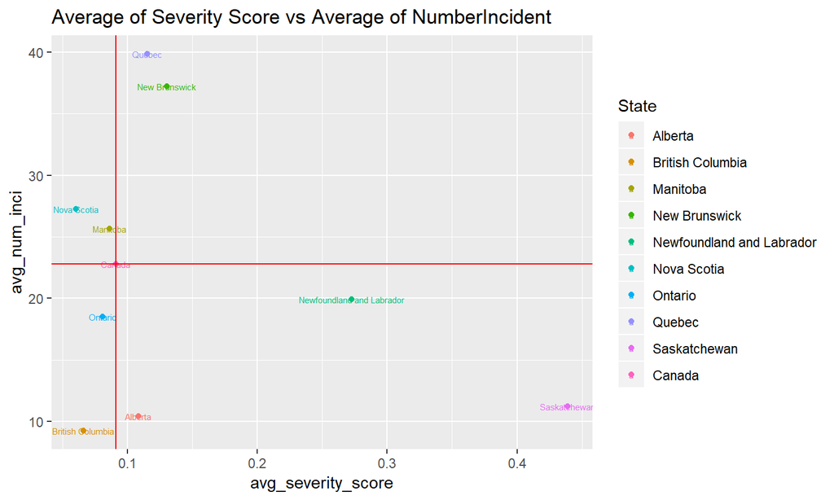

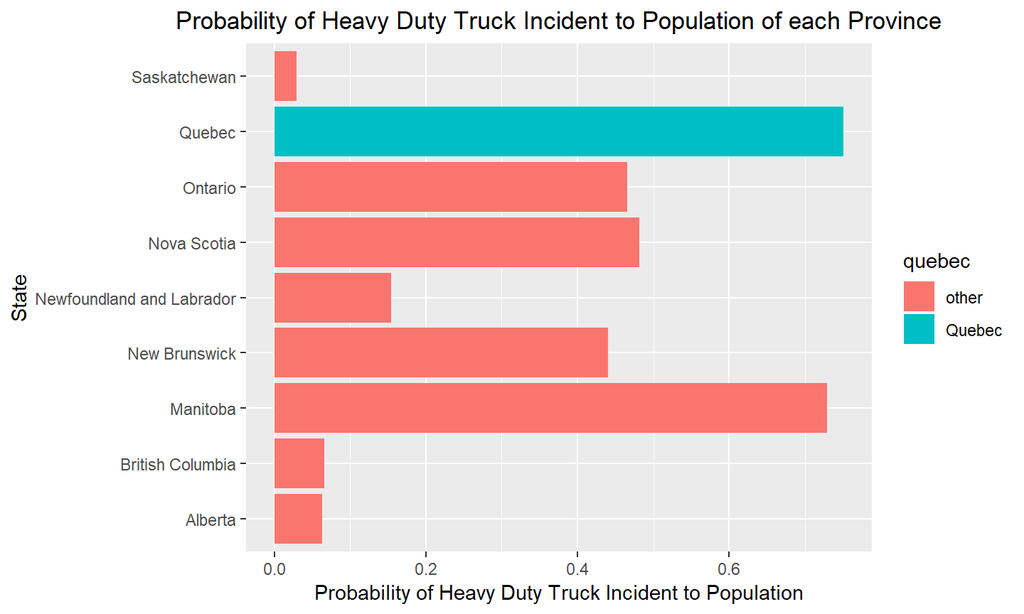

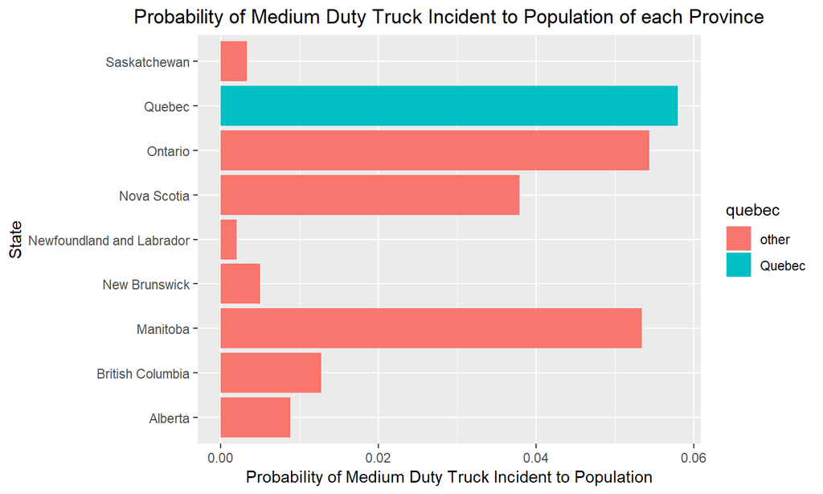

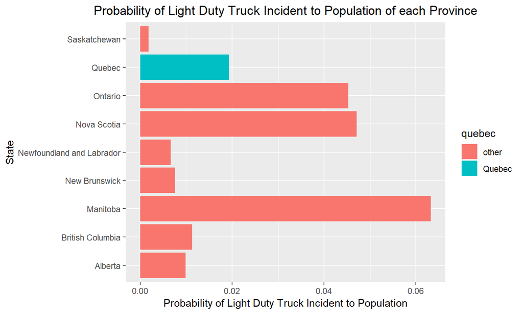

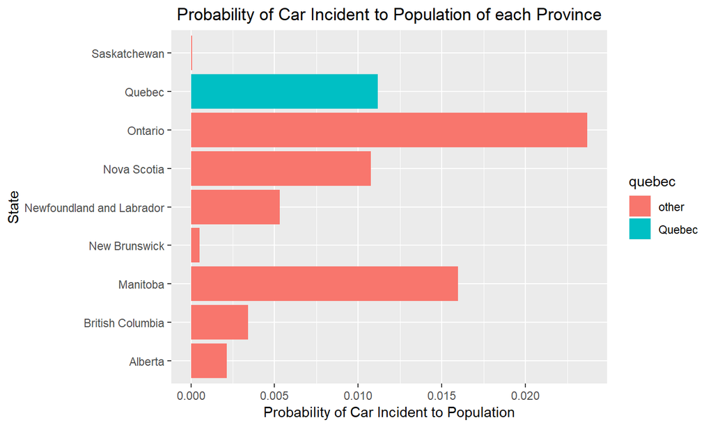

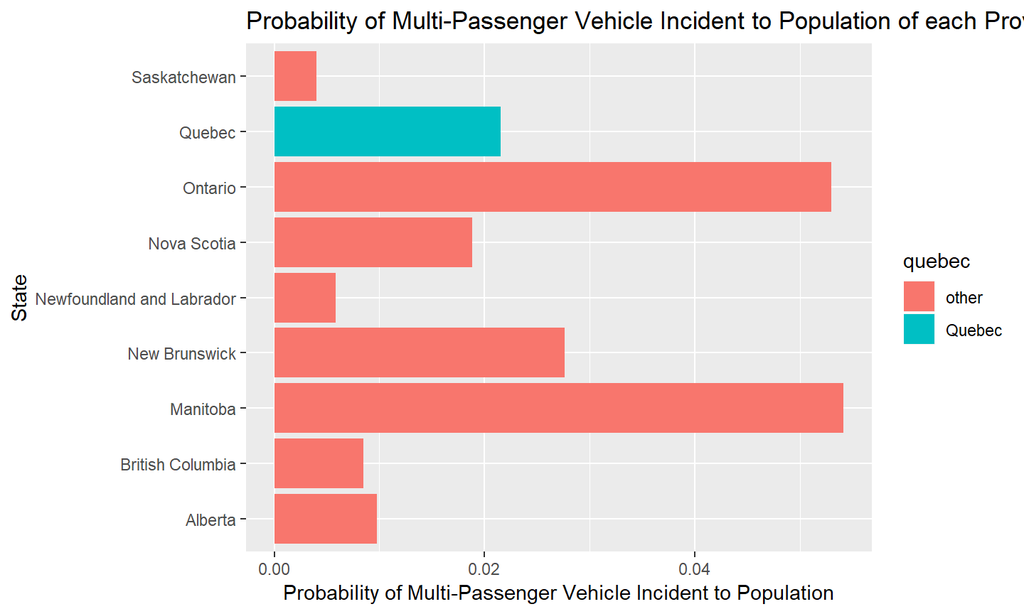

## Classification Tree

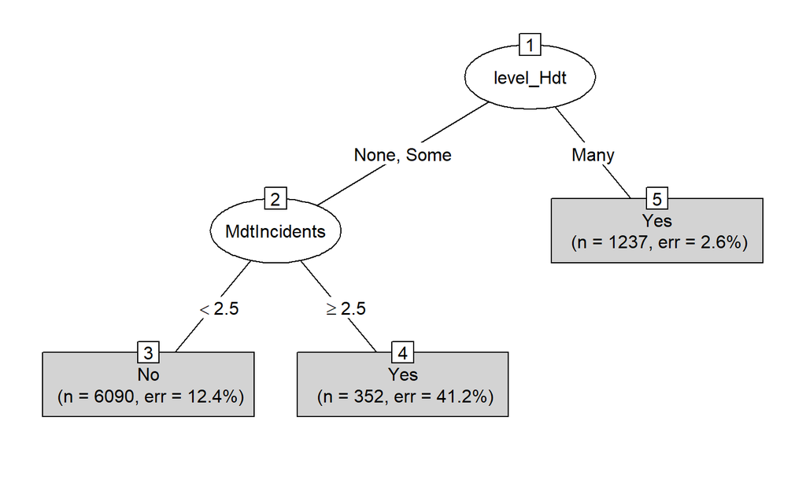

## ROC

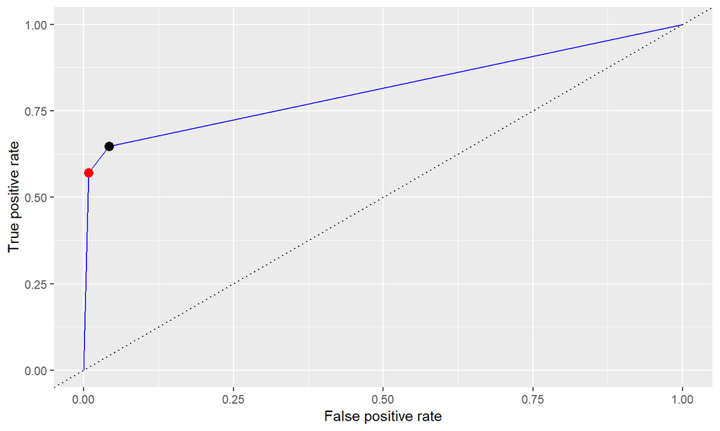

## Results

- Base on the data, we discovered that the Saskatchewan and the Newfoundland and Labrador are the most two hazardous driving area
- However, since they have the smallest dataset which their datasets are less than 50, so we cannot use them to satisfy our prediction.
- As the results, we find Quebec is the most hazardous driving area.
- Classification Tree
- Two significant main effects – the number of incidents involving a medium-duty truck and a heavy-duty truck in Quebec state (from the figure P_Hdt and P_Mdt).

## Proportion of Hazardous Area in Each Province

```
## # A tibble: 9 x 4
##   State                     num_yes total proportion
##   <fct>                       <int> <int>      <dbl>
## 1 Newfoundland and Labrador      28    49       57.1
## 2 Quebec                        882  2128       41.4
## 3 Saskatchewan                   19    46       41.3
## 4 New Brunswick                  46   120       38.3
## 5 Nova Scotia                    62   243       25.5
## 6 Manitoba                      153   601       25.5
## 7 Ontario                      1467  5909       24.8
## 8 Alberta                        96   477       20.1
## 9 British Columbia              130   666       19.5
```

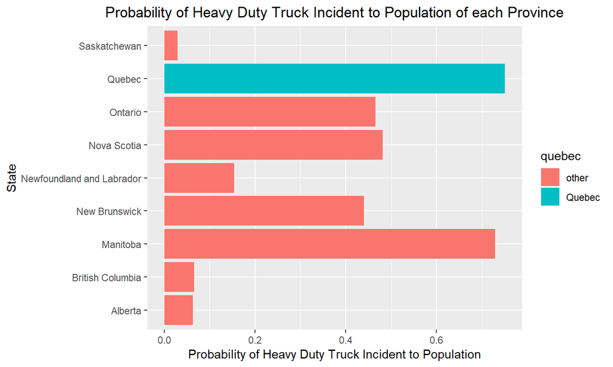

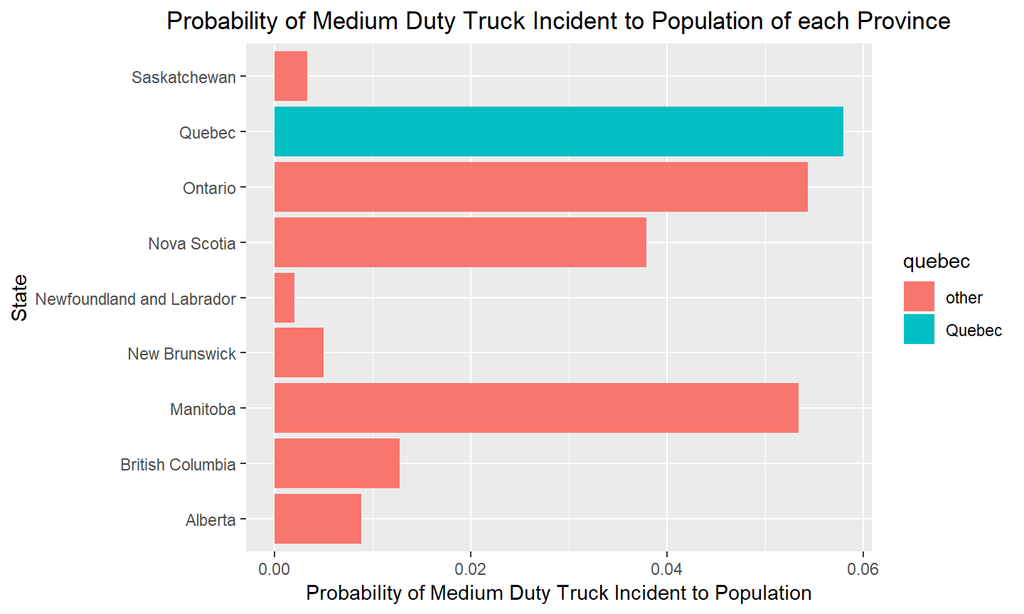

## Conclusion

- **conclusion**: Quebec is the most Hazardous driving province
- -> Highest probability of Heavy and Medium Duty Truck Incidents
- **limitation** : may only work for this specific data set
- **error** : Newfoundland and Labrador has the highest proportion of hazardous driving area, it does not match our definition of hazardous driving area

## Reference

“Canadian Motor Vehicle Traffic Collision Statistics: 2015.” Goverment of Canada -Transport Canada, 26 May 2017, www.tc.gc.ca/eng/motorvehiclesafety/tp-tp3322-2015-1487.html.

“Hazardous Driving Areas.” Geotab Data, 13 Mar. 2018, data.geotab.com/urban-infrastructure/hazardous-driving.

Statistics Canada. “Population and Dwelling Count Highlight Tables, 2011 Census.”Government of Canada, Statistics Canada, 9 Aug. 2016, www12.statcan.ca/census-recensement/2011/dp-pd/hlt-fst/pd-pl/Table-Tableau.cfm?LANG=Eng&T=301&SR=1&S=3&O=D&RPP=25&PR=0&CMA=0.